# Intro to DS - KNN Classifiers: PIMA dataset

GWU Intro to Data Science DATS 6101

2022-11-16

# HW Assignment - KNN

This exercise uses the Pima.te and Pima.tr dataset from the MASS package, which includes measurement on a population of women of Pima Indian heritage living near Phoenix, Arizona. The women were tested for diabetes according to World Health Organization criteria. We are interested in predicting diabetes status as a function of the other variables.

The variables in the dataset are:

- `npreg` : number of pregnancies.
- `glu` : plasma glucose concentration
- `bp` : diastolic blood pressure (mm Hg) skin triceps skinfold thickness (mm)
- `bmi` : body mass index
- `ped` : diabetes pedigree function
- `age` : age in years
- `type` : Yes or No: diabetic by WHO criteria

## Pima Dataset

### Question 1

**Obtain the dataset**  
In the `MASS` library, combine the two datasets `Pima.te` and `Pima.tr` back into one complete dataset, call it `pima`. (Try function `rbind()`.) How many observations are there?

### Question 2

**Summary**  
Obtain some basic summary statistics for the full dataset `pima`.

### Question 3

**Pairs**  
Another quick EDA to perform, you can plot the `pairs()`. The plot function can handle both numerical and categorical variable type. After trying the function in the R base library, also try the modified version with `pairs.panels()`. Comment on interesting relationships.

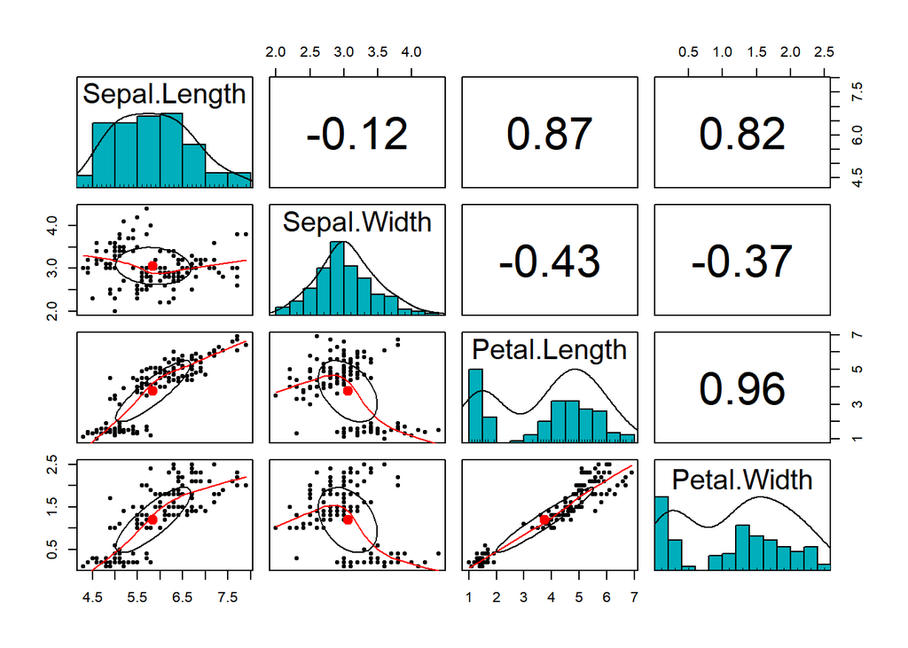

```r
## Example of pairs.panel on the iris data set -- edit for your analysis of the pima data ##
loadPkg("psych")
pairs.panels(iris[,-5],
             method = "pearson", # correlation method
             hist.col = "#00AFBB", # set histogram color, can use "#22AFBB", "red",
             density = TRUE,  # show density plots
             ellipses = TRUE # show correlation ellipses
             )
```

```r
unloadPkg("psych")
```

## KNN

### Question 4

**Train-Test split 3:1**  
First, standardize all of the X variables (i.e. all by `type`). Now, in order to perform KNN analysis, we need to separate the X variables and the y variable `type`. Before we separate them out, create a vector/array of 1s and 2s to create a train-test split in the ratio of 3:1 (i.e. 75% training, 25% test). Make sure to set a constant seed value (e.g. using `set.seed`) so that you can duplicate the results. You should end up with a dataframe of Xs for training with the corresponding vector of y, and a dataframe of Xs for testing with the corresponding vector of y. Make sure the order of observations in train-X and train-y are not mixed up during the process. Same for test-X and test-y.

### Question 5

**KNN results**  
Perform the KNN analysis, with different k values. You do not need to show all the results from different k, but please include the one with the best (total) accuracy in your submission. How does the accuracy compared to the percentages of being T/F in the dataset?

## Logistic Regression and comparison

### Question 6

**Logistic Regression results**  
Compare to the best logistic regression you can get. (Use the full model with all variables, since that is what we have for KNN.) How is the accuracy (assumes the standard cutoff of 0.5) compared to KNN?

### Question 7

**ROC-AUC**  
What is the AUC for the logit model? Plot the ROC. We should be able to compute the ROC and AUC for the KNN model the same way. Can you compare them?